# AI Impact on Jobs 2030 - Descriptive Analysis

## Notebook 1 : Introduction

As artificial intelligence continues to transform the workplace, questions arise about which jobs are most at risk of automation. Some occupations may be highly exposed to AI-driven technologies, while others rely on uniquely human skills that are less easily automated.

This project draws on a dataset simulating the future of work in 2030, including 3,000 observations with information on salary, experience, education, AI exposure, and automation risk.

The primary question guiding this descriptive analysis is:

**“Which types of jobs are most at risk of automation, and how do job characteristics are distributed across different levels of automation risk?”**

Through this exploration, we aim to identify patterns and insights that highlight the potential impact of AI on the workforce, without making predictive or causal claims.

Author: J-F Jutras  
Date: December 2025  
Dataset: AI Impact on Jobs 2030 — Kaggle

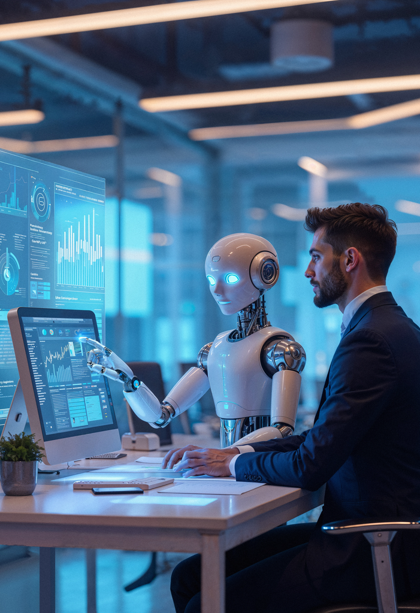

AI Illustration: Man and robot working together in a high-tech office (Freepik)

## Data Loading and Overview

**First 10 rows of the AI Impact on Jobs 2030 dataset**

| Job_Title | Average_Salary | Years_Experience | Education_Level | AI_Exposure_Index | Tech_Growth_Factor | Automation_Probability_2030 | Risk_Category | Skill_1 | Skill_2 | Skill_3 | Skill_4 | Skill_5 | Skill_6 | Skill_7 | Skill_8 | Skill_9 | Skill_10 |
| --- | --- | --- | --- | --- | --- | --- | --- | --- | --- | --- | --- | --- | --- | --- | --- | --- | --- |
| Security Guard | 45795 | 28 | Master’s | 0.18 | 1.28 | 0.85 | High | 0.45 | 0.10 | 0.46 | 0.33 | 0.14 | 0.65 | 0.06 | 0.72 | 0.94 | 0.00 |
| Research Scientist | 133355 | 20 | PhD | 0.62 | 1.11 | 0.05 | Low | 0.02 | 0.52 | 0.40 | 0.05 | 0.97 | 0.23 | 0.09 | 0.62 | 0.38 | 0.98 |
| Construction Worker | 146216 | 2 | High School | 0.86 | 1.18 | 0.81 | High | 0.01 | 0.94 | 0.56 | 0.39 | 0.02 | 0.23 | 0.24 | 0.68 | 0.61 | 0.83 |
| Software Engineer | 136530 | 13 | PhD | 0.39 | 0.68 | 0.60 | Medium | 0.43 | 0.21 | 0.57 | 0.03 | 0.84 | 0.45 | 0.40 | 0.93 | 0.73 | 0.33 |
| Financial Analyst | 70397 | 22 | High School | 0.52 | 1.46 | 0.64 | Medium | 0.75 | 0.54 | 0.59 | 0.97 | 0.61 | 0.28 | 0.30 | 0.17 | 0.02 | 0.42 |
| AI Engineer | 92592 | 11 | Master’s | 0.29 | 0.51 | 0.10 | Low | 0.71 | 0.79 | 0.61 | 0.93 | 0.65 | 0.91 | 0.85 | 0.45 | 0.10 | 0.37 |
| Mechanic | 107373 | 23 | PhD | 0.67 | 1.09 | 0.41 | Medium | 0.56 | 0.38 | 0.97 | 0.85 | 0.72 | 0.24 | 0.26 | 0.04 | 0.71 | 0.11 |
| Teacher | 53419 | 12 | High School | 0.20 | 1.40 | 0.17 | Low | 0.56 | 0.70 | 0.14 | 0.60 | 0.54 | 0.20 | 0.94 | 0.60 | 0.69 | 0.88 |
| HR Specialist | 139225 | 12 | Master’s | 0.30 | 0.61 | 0.48 | Medium | 0.22 | 0.42 | 0.88 | 0.32 | 0.12 | 0.36 | 0.91 | 0.27 | 0.65 | 0.00 |
| Customer Support | 85016 | 2 | High School | 0.01 | 1.01 | 0.80 | High | 0.22 | 0.12 | 0.34 | 0.94 | 0.32 | 0.52 | 0.70 | 0.36 | 0.97 | 0.96 |

**Description of Dataset Columns for AI Impact on Jobs 2030**

| Column | Description |
| --- | --- |
| Job_Title | Name of the occupation (e.g., Data Scientist, Truck Driver) |
| Average_Salary | Average annual salary for the job (USD) |
| Years_Experience | Average years of experience typically required |
| Education_Level | Highest common level of education required (High School, Bachelor’s, Master’s, PhD) |
| AI_Exposure_Index | How much the job interacts with AI tools (0 = no exposure, 1 = highly AI-dependent) |
| Tech_Growth_Factor | Multiplier representing how quickly technology is advancing in the field |
| Automation_Probability_2030 | Estimated probability that the job will be automated by 2030 |
| Risk_Category | Categorized automation risk: Low, Medium, or High |
| Skill_1 | Randomized skill proficiency levels for one of 10 skill dimensions |
| Skill_2 | Randomized skill proficiency levels for one of 10 skill dimensions |
| Skill_3 | Randomized skill proficiency levels for one of 10 skill dimensions |
| Skill_4 | Randomized skill proficiency levels for one of 10 skill dimensions |
| Skill_5 | Randomized skill proficiency levels for one of 10 skill dimensions |
| Skill_6 | Randomized skill proficiency levels for one of 10 skill dimensions |
| Skill_7 | Randomized skill proficiency levels for one of 10 skill dimensions |
| Skill_8 | Randomized skill proficiency levels for one of 10 skill dimensions |
| Skill_9 | Randomized skill proficiency levels for one of 10 skill dimensions |
| Skill_10 | Randomized skill proficiency levels for one of 10 skill dimensions |

**General Information about the Dataset**

| Metric | Value |
| --- | --- |
| Number of rows | 3000 |
| Number of columns | 18 |
| Duplicate rows | 0 |

**Variables Overview**

|  | Column | Type | Missing | Missing_Percent |
| --- | --- | --- | --- | --- |
| Job_Title | Job_Title | character | 0 | 0 |
| Average_Salary | Average_Salary | numeric | 0 | 0 |
| Years_Experience | Years_Experience | numeric | 0 | 0 |
| Education_Level | Education_Level | character | 0 | 0 |
| AI_Exposure_Index | AI_Exposure_Index | numeric | 0 | 0 |
| Tech_Growth_Factor | Tech_Growth_Factor | numeric | 0 | 0 |
| Automation_Probability_2030 | Automation_Probability_2030 | numeric | 0 | 0 |
| Risk_Category | Risk_Category | character | 0 | 0 |
| Skill_1 | Skill_1 | numeric | 0 | 0 |
| Skill_2 | Skill_2 | numeric | 0 | 0 |
| Skill_3 | Skill_3 | numeric | 0 | 0 |
| Skill_4 | Skill_4 | numeric | 0 | 0 |
| Skill_5 | Skill_5 | numeric | 0 | 0 |
| Skill_6 | Skill_6 | numeric | 0 | 0 |
| Skill_7 | Skill_7 | numeric | 0 | 0 |
| Skill_8 | Skill_8 | numeric | 0 | 0 |
| Skill_9 | Skill_9 | numeric | 0 | 0 |
| Skill_10 | Skill_10 | numeric | 0 | 0 |

**Statistical Summary of Numeric Variables**

| Variable | Min | 1st Qu. | Median | Mean | 3rd Qu. | Max |
| --- | --- | --- | --- | --- | --- | --- |
| Average_Salary | 30030.00 | 58640.00 | 89318.000 | 89372.279 | 119086.50 | 149798.00 |
| Years_Experience | 0.00 | 7.00 | 15.000 | 14.678 | 22.00 | 29.00 |
| AI_Exposure_Index | 0.00 | 0.26 | 0.500 | 0.501 | 0.74 | 1.00 |
| Tech_Growth_Factor | 0.50 | 0.74 | 1.000 | 0.995 | 1.24 | 1.50 |
| Automation_Probability_2030 | 0.05 | 0.31 | 0.500 | 0.502 | 0.70 | 0.95 |
| Skill_1 | 0.00 | 0.24 | 0.505 | 0.497 | 0.74 | 1.00 |
| Skill_2 | 0.00 | 0.25 | 0.500 | 0.497 | 0.74 | 1.00 |
| Skill_3 | 0.00 | 0.25 | 0.500 | 0.499 | 0.75 | 1.00 |
| Skill_4 | 0.00 | 0.26 | 0.510 | 0.504 | 0.75 | 1.00 |
| Skill_5 | 0.00 | 0.24 | 0.490 | 0.490 | 0.73 | 1.00 |
| Skill_6 | 0.00 | 0.26 | 0.500 | 0.500 | 0.74 | 1.00 |
| Skill_7 | 0.00 | 0.25 | 0.490 | 0.499 | 0.75 | 1.00 |
| Skill_8 | 0.00 | 0.25 | 0.500 | 0.503 | 0.75 | 1.00 |
| Skill_9 | 0.00 | 0.26 | 0.500 | 0.501 | 0.74 | 1.00 |
| Skill_10 | 0.00 | 0.25 | 0.490 | 0.494 | 0.74 | 1.00 |

**Summary of Initial Findings**

This initial descriptive exploration confirms that the AI Impact on Jobs 2030 dataset is well-structured and suitable for illustrating patterns related to automation risk. Covering 3,000 observations for 20 different job titles with no missing values and no duplicates, the dataset includes a balanced mix of economic, educational, and technological variables. Although the data are simulated, they provide a clear framework for exploring automation probabilities, AI exposure, and risk categories across different job types.

Preliminary statistics indicate substantial variation across jobs in terms of salary, experience, AI exposure, and estimated automation probability, with central tendencies suggesting moderate average exposure to AI and a wide dispersion of automation risk by 2030. The diversity observed across education levels, risk categories, and skill profiles highlights the heterogeneity of the future labor market and suggests that automation risk is unlikely to be uniform across occupations.

For the purpose of this project, the ten skill variables (Skill_1 to Skill_10) are excluded from the initial univariate analysis. These variables are randomized proficiency levels representing different skill dimensions (e.g., creativity, data analysis, robotics). Focusing on variables like Years_Experience, AI_Exposure_Index, Tech_Growth_Factor, and Automation_Probability_2030 allows for clear, interpretable visualizations that highlight meaningful patterns in automation risk.

These initial findings provide a solid foundation for deeper descriptive analyses examining how job characteristics such as experience, education, and AI exposure relate to automation vulnerability, without making predictive or causal claims.

## Univariate Analysis

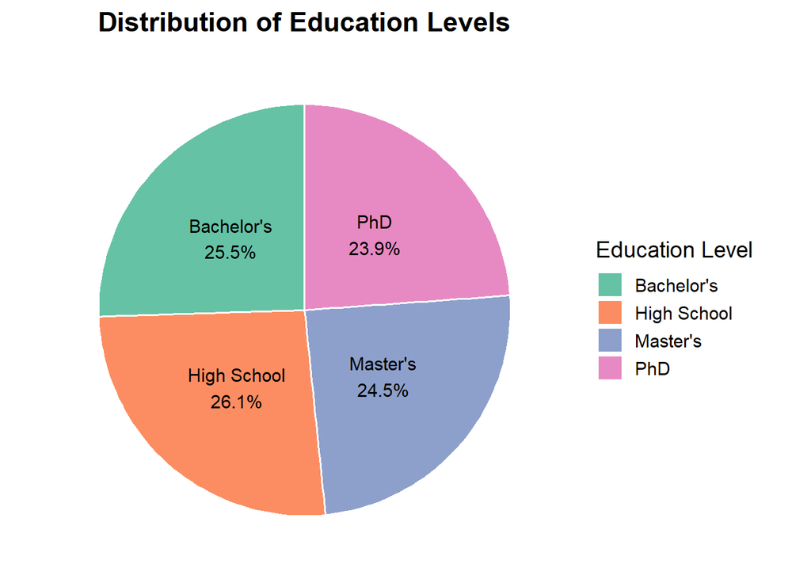

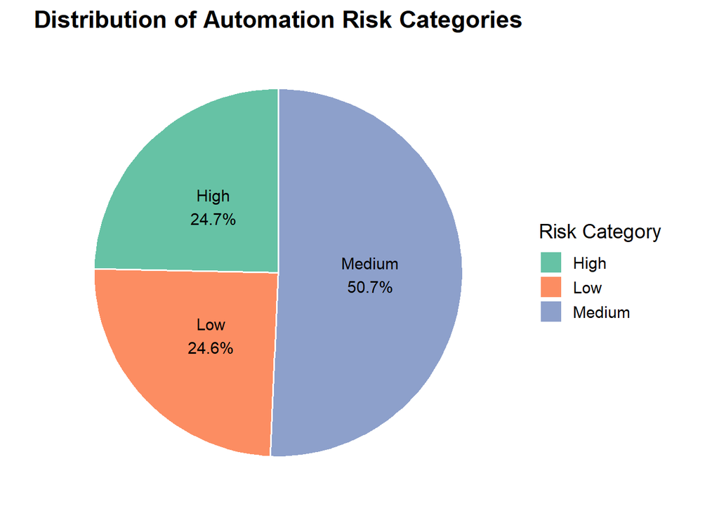

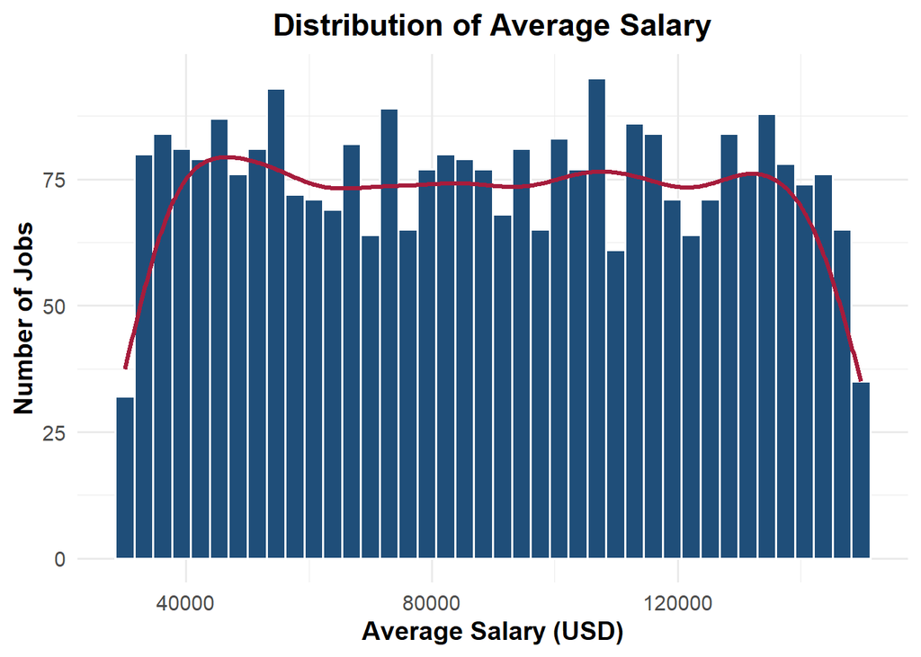

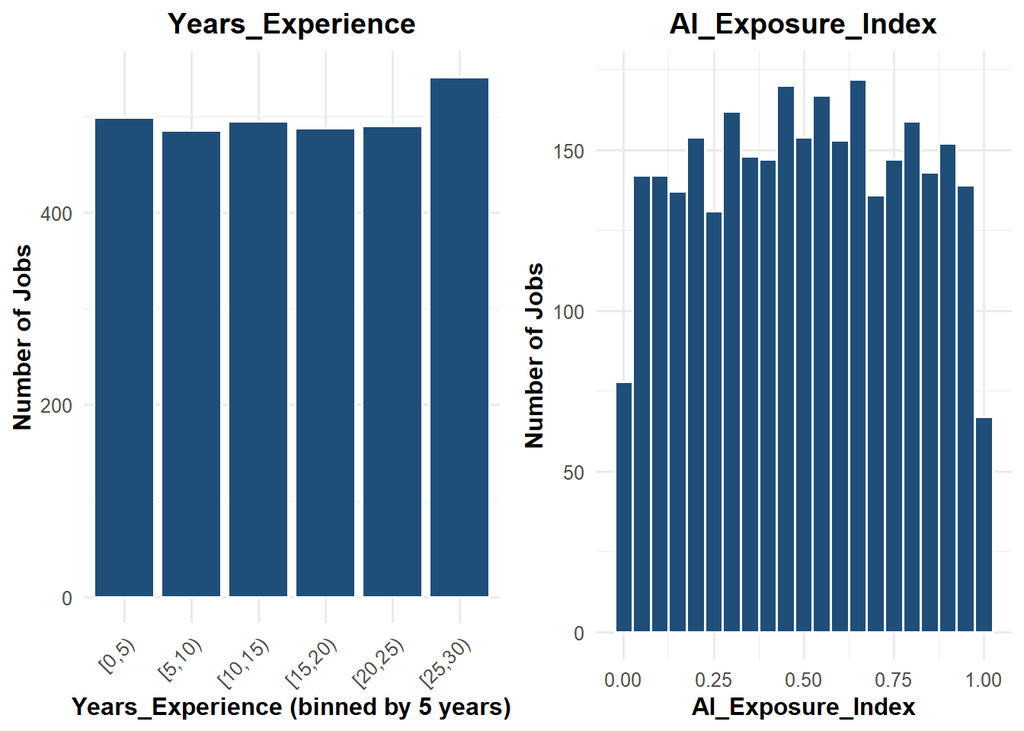

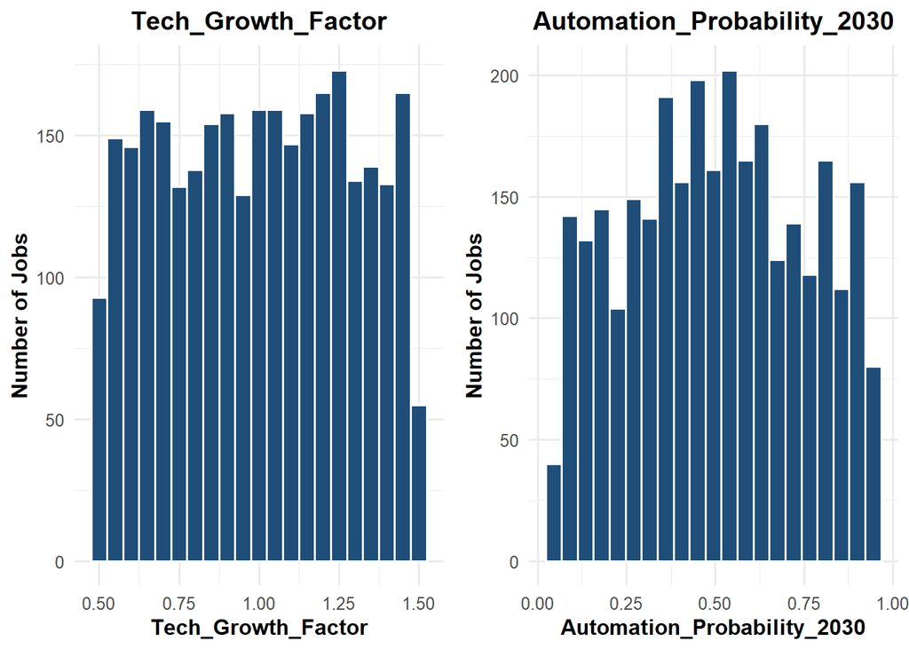

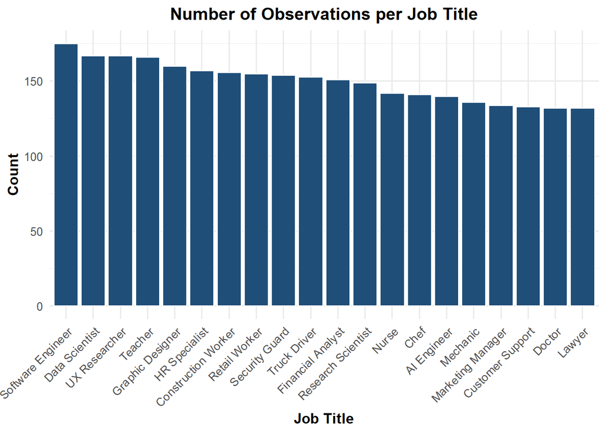

**Key Takeaways: Univariate Analysis**

- **Average Salary** ranges from $30,030 to $149,798, with a median of $89,318 and mean of $89,372, indicating a relatively symmetric distribution of salaries across occupations.
- **Years of Experience** spans from 0 to 29 years, with a median of 15 and a mean of 14.7, showing a fairly even distribution with a slight skew towards lower experience levels.
- **AI Exposure Index** varies from 0 to 1, with a median and mean around 0.5, reflecting a balanced distribution of AI dependence across jobs.
- **Tech Growth Factor** ranges from 0.5 to 1.5, with a median of 1.0, suggesting most fields experience moderate technological growth.
- **Automation Probability 2030** spans from 0.05 to 0.95, with a median of 0.5, highlighting that automation risk is distributed across the spectrum, with many jobs at moderate risk.
- **Job Titles** includes 20 unique job titles, with counts ranging from 132 to 175, showing a balanced representation across technical, creative, healthcare, and service occupations.

## Multivariate Analysis

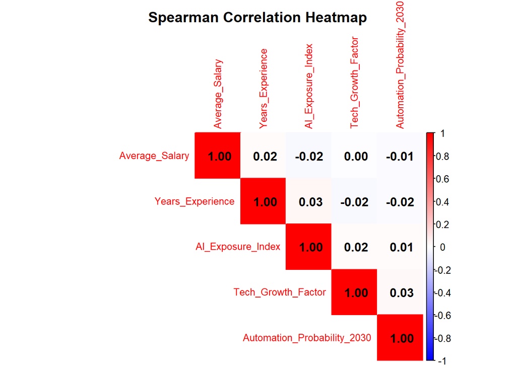

A Spearman correlation analysis was conducted on the key numerical variables (Average_Salary, Years_Experience, AI_Exposure_Index, Tech_Growth_Factor, and Automation_Probability_2030), and the results indicate that the correlations between these variables are very weak, with the coefficients being between 0.03 and -0.02. This suggests that, across all occupations, these numerical features vary largely independently of each other, highlighting the diversity and heterogeneity of jobs in the dataset.

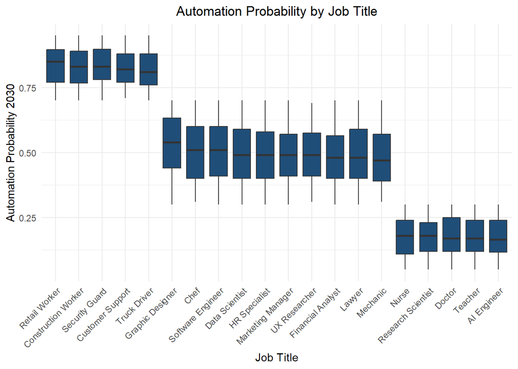

The visualization highlights strong heterogeneity in automation probability across job titles, with routine and manual roles such as Retail Worker, Construction Worker, Security Guard, Customer Support, and Truck Driver exhibiting the highest median automation risk (approximately 0.81–0.85), while more technical, analytical, or creative occupations—including Software Engineer, Data Scientist, Graphic Designer, Chef, and HR Specialist—show lower median probabilities (around 0.49–0.54).

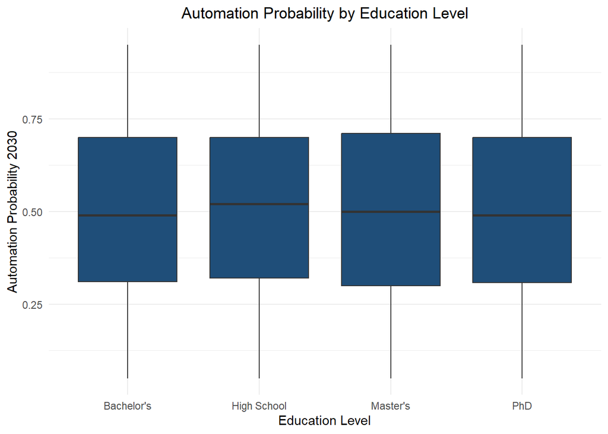

The visualization shows that automation probability varies across education levels, but no clear monotonic relationship is observed. All education categories display substantial within-group dispersion, indicating that jobs requiring similar levels of education can nonetheless face very different degrees of automation risk. This suggests that education level alone is not sufficient to explain automation vulnerability across occupations, and that other factors such as task composition and technological exposure likely play a significant role.

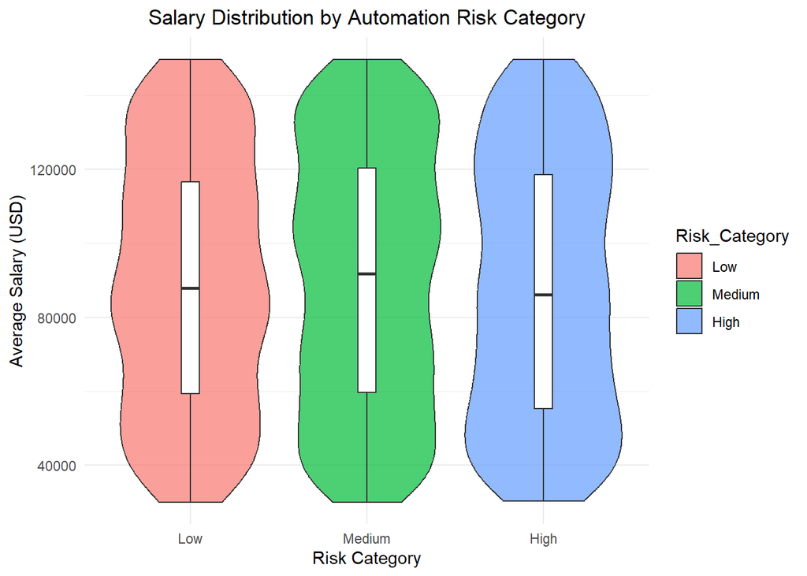

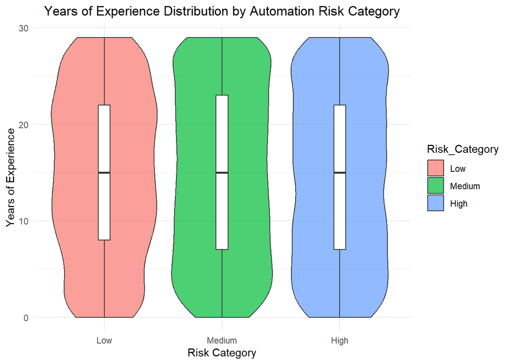

These violin plots illustrate the distributions of salary and years of experience across automation risk categories by combining density estimates with boxplot summaries. For both variables, a strong overlap is observed between low-, medium-, and high-risk jobs, suggesting that salary levels and experience are broadly comparable across risk categories.

While the plots clearly display the spread and shape of each distribution, no automation risk group exhibits a distinctly different pattern. Overall, these results indicate that automation risk is not strongly differentiated by either wage or years of experience in this dataset.

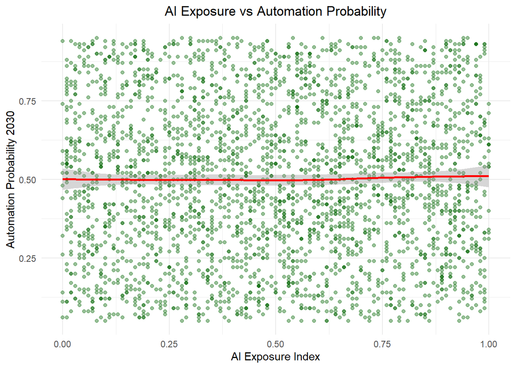

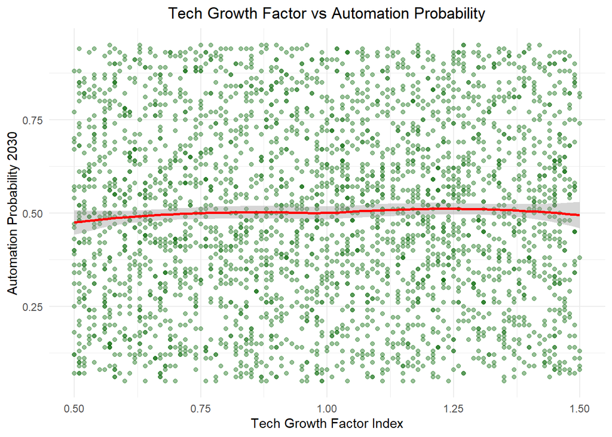

These scatter plots examine the relationships between automation probability and two technological variables (AI exposure and the Tech Growth Factor) using LOESS smoothing to capture potential non-linear patterns. In both cases, the smoothed trends appear relatively flat, and the data points show substantial dispersion across all levels of exposure and technological growth. No strong or consistent association is visually apparent, suggesting that neither higher interaction with AI tools nor faster technological growth within a field is, on its own, a strong determinant of automation risk.

These observations indicate that technological factors alone may have a limited explanatory role in automation vulnerability, and that automation outcomes likely depend on a more complex combination of task characteristics and contextual factors.

**Distribution of Automation Risk by Education Level**

| Education_Level | Low | Medium | High |
| --- | --- | --- | --- |
| Bachelor’s | 24.8% | 50.6% | 24.6% |
| High School | 23.2% | 52.9% | 23.9% |
| Master’s | 25.6% | 48.8% | 25.6% |
| PhD | 25.0% | 50.3% | 24.7% |

The cross-tabulation shows that automation risk is fairly evenly distributed across all education levels. Most jobs fall into the medium-risk category, while low- and high-risk jobs are roughly balanced for each education level. This indicates that education alone does not strongly determine automation vulnerability, and other factors such as job type, tasks, and technological exposure likely play a more important role.

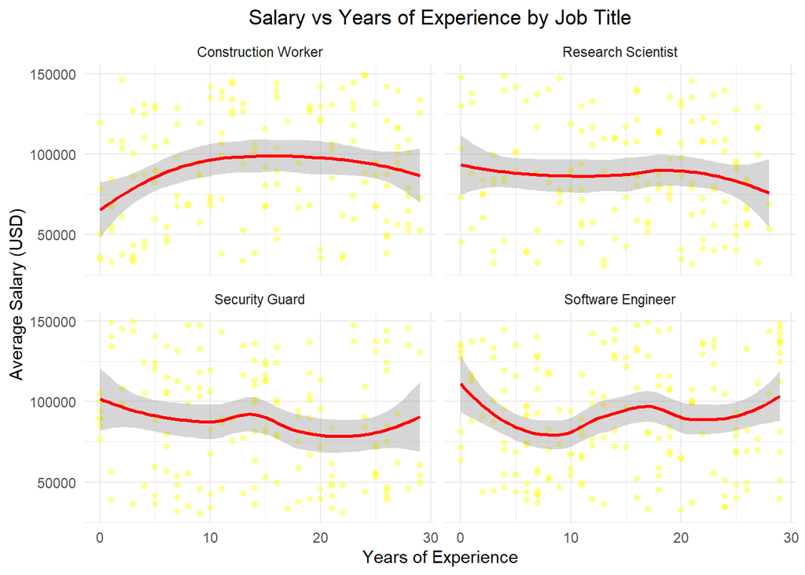

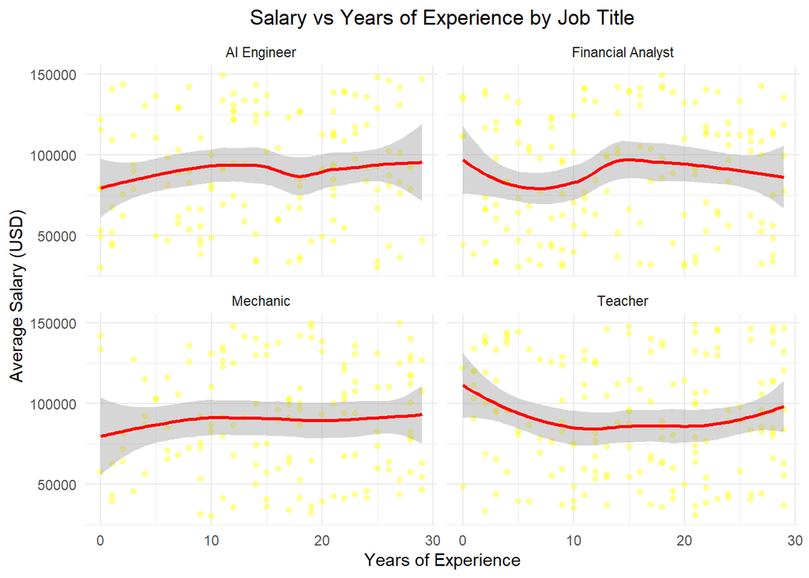

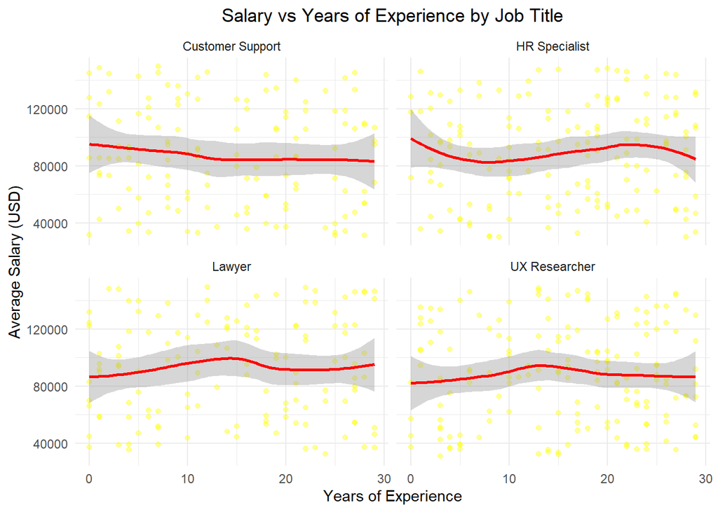

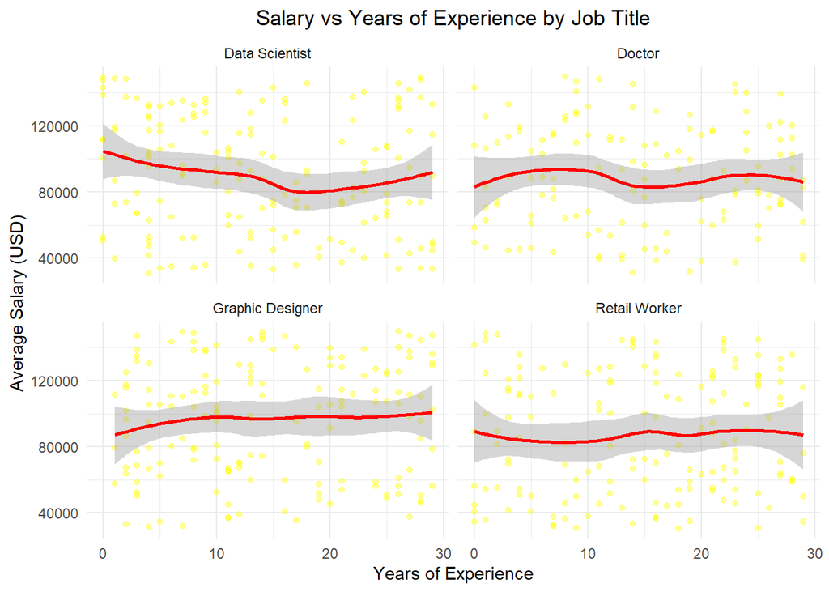

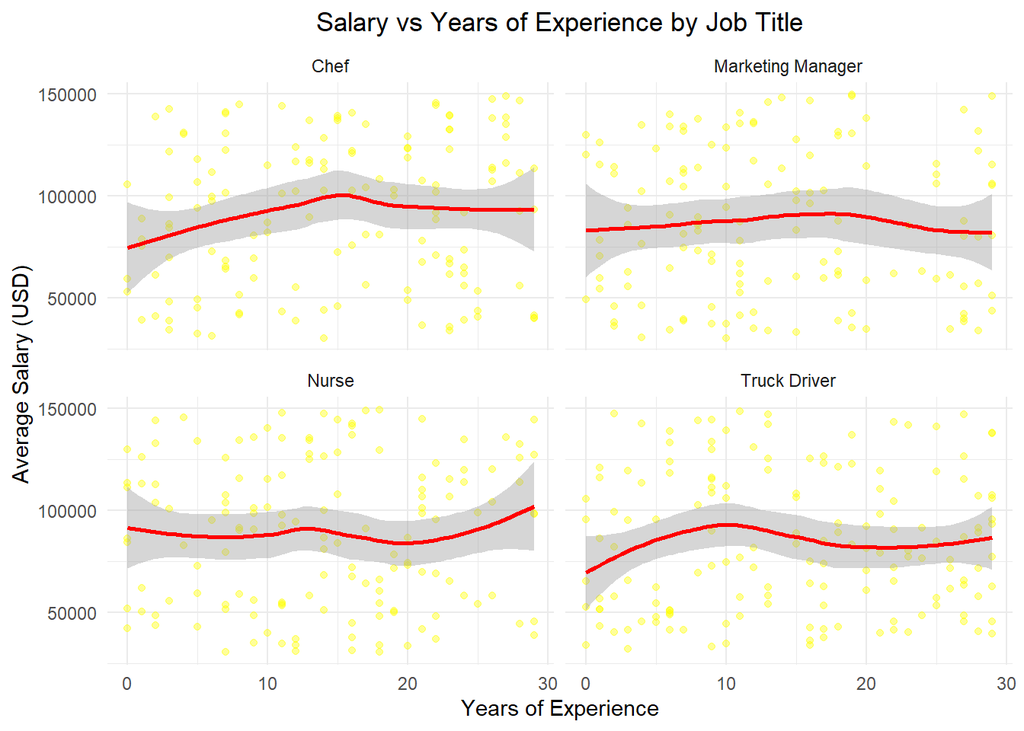

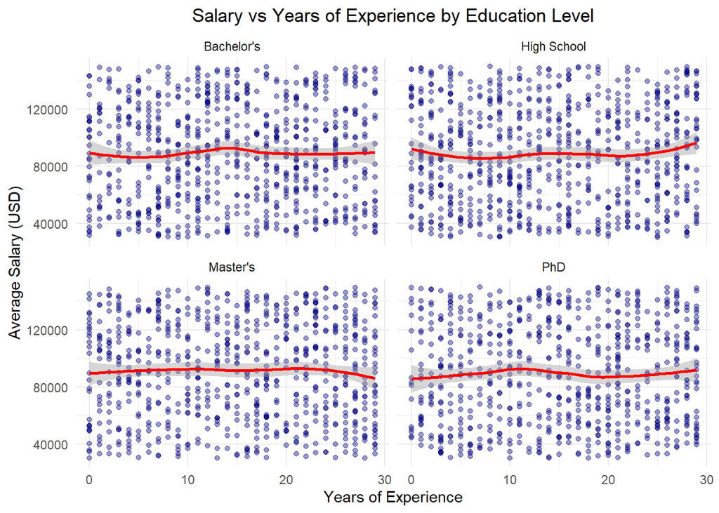

These faceted scatter plots describe how salary and years of experience are jointly distributed across job titles and education levels, using LOESS curves to summarize overall patterns. In both cases, the association between experience and salary appears weak and highly variable, with no clear or consistent upward trend as experience increases. Differences in typical salary levels are visible across job titles and education groups, but substantial dispersion is observed within each group.

Overall, these visualizations highlight strong heterogeneity in salary–experience patterns across occupations and education levels, with wide ranges of values present even among individuals with similar experience.

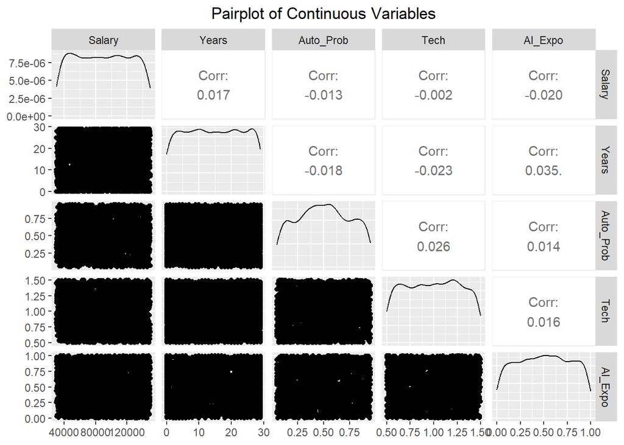

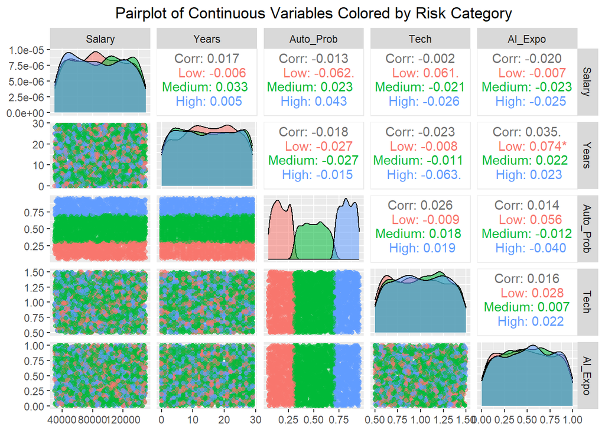

The pairplots, both at the global level and when stratified by automation risk category, reveal very weak associations among salary, years of experience, automation probability, AI exposure, and the tech growth factor. Across all visualizations, the scatterplots are highly dispersed and the corresponding Spearman correlations remain close to zero, indicating the absence of strong monotonic patterns between the continuous variables. This diffuse structure persists within low-, medium-, and high-risk groups, suggesting that stratifying by risk does not uncover more pronounced relationships.

Overall, these visualizations highlight substantial heterogeneity in the data and indicate that the continuous variables vary largely independently across the dataset.

**Summary Statistics by Education Level**

| Education_Level | Mean_Salary | Median_Salary | Mean_Years_Experience | Median_Years_Experience | Mean_AI_Exposure | Median_AI_Exposure | Mean_Tech_Growth | Median_Tech_Growth | Mean_Automation_Probability | Median_Automation_Probability |
| --- | --- | --- | --- | --- | --- | --- | --- | --- | --- | --- |
| Bachelor’s | 88815.49 | 89309.0 | 14.531 | 14 | 0.497 | 0.49 | 1.010 | 1.03 | 0.500 | 0.49 |
| High School | 88389.29 | 87709.5 | 14.204 | 14 | 0.498 | 0.50 | 0.992 | 0.98 | 0.509 | 0.52 |
| Master’s | 91318.57 | 92086.0 | 14.924 | 15 | 0.503 | 0.50 | 0.992 | 0.99 | 0.496 | 0.50 |
| PhD | 89045.57 | 87818.5 | 15.101 | 15 | 0.508 | 0.52 | 0.987 | 1.00 | 0.500 | 0.49 |

The summary statistics by education level reveal that average salaries are relatively similar across groups, ranging from $88,389 for High School graduates to $91,319 for Master’s degree holders, with median salaries showing the same modest differences.

Years of experience are also fairly consistent, with mean values between 14.2 and 15.1 years, indicating that higher education levels do not correspond to substantially more experience on average.

AI exposure and Tech Growth factors are balanced across education levels, with mean AI exposure around 0.50 and Tech Growth factors close to 1, suggesting that the technological environment does not differ dramatically by education.

Finally, automation probability is broadly similar across groups, with median values near 0.49–0.52, highlighting that education alone does not strongly differentiate occupations in terms of automation risk.

Overall, these results indicate modest differences across education levels, and suggest that other factors beyond education likely drive variation in salary, AI exposure, and automation probability.

**Summary Statistics by Job Title**

| Job_Title | Mean_Salary | Median_Salary | Mean_Years_Experience | Median_Years_Experience | Mean_AI_Exposure | Median_AI_Exposure | Mean_Tech_Growth | Median_Tech_Growth | Mean_Automation_Prob | Median_Automation_Prob |
| --- | --- | --- | --- | --- | --- | --- | --- | --- | --- | --- |
| AI Engineer | 90759.83 | 90705.0 | 14.443 | 14.0 | 0.474 | 0.445 | 0.979 | 0.980 | 0.172 | 0.165 |
| Chef | 91407.80 | 94043.0 | 14.929 | 15.0 | 0.529 | 0.520 | 1.081 | 1.150 | 0.496 | 0.510 |
| Construction Worker | 90800.33 | 89613.0 | 14.558 | 14.5 | 0.505 | 0.550 | 0.998 | 0.990 | 0.826 | 0.830 |
| Customer Support | 87487.00 | 86153.0 | 14.000 | 13.0 | 0.502 | 0.530 | 0.991 | 1.010 | 0.825 | 0.820 |
| Data Scientist | 90629.55 | 91063.0 | 13.898 | 13.0 | 0.513 | 0.510 | 0.960 | 0.940 | 0.496 | 0.490 |
| Doctor | 89091.74 | 88326.5 | 14.674 | 14.0 | 0.505 | 0.490 | 0.964 | 0.955 | 0.177 | 0.170 |
| Financial Analyst | 88030.31 | 91146.0 | 14.351 | 14.0 | 0.464 | 0.470 | 1.028 | 1.050 | 0.485 | 0.480 |
| Graphic Designer | 96423.47 | 103183.0 | 14.631 | 13.0 | 0.527 | 0.510 | 0.993 | 1.005 | 0.529 | 0.540 |
| HR Specialist | 89242.26 | 93115.0 | 15.439 | 17.0 | 0.489 | 0.500 | 0.987 | 1.010 | 0.491 | 0.490 |
| Lawyer | 92441.88 | 95140.0 | 14.720 | 15.5 | 0.509 | 0.495 | 1.015 | 1.045 | 0.486 | 0.480 |
| Marketing Manager | 86458.11 | 85592.0 | 13.515 | 12.0 | 0.524 | 0.520 | 1.012 | 1.025 | 0.495 | 0.490 |
| Mechanic | 89807.65 | 91075.5 | 16.228 | 17.0 | 0.457 | 0.445 | 0.976 | 0.980 | 0.485 | 0.470 |
| Nurse | 88955.32 | 91926.0 | 14.000 | 14.0 | 0.521 | 0.540 | 0.986 | 0.975 | 0.176 | 0.180 |
| Research Scientist | 87204.74 | 84544.0 | 14.839 | 16.0 | 0.479 | 0.480 | 0.962 | 0.980 | 0.174 | 0.180 |
| Retail Worker | 87208.41 | 84150.0 | 14.839 | 16.0 | 0.506 | 0.520 | 0.997 | 0.990 | 0.835 | 0.850 |
| Security Guard | 87290.43 | 88584.5 | 14.201 | 14.0 | 0.515 | 0.525 | 0.987 | 0.970 | 0.833 | 0.830 |
| Software Engineer | 90264.74 | 87803.0 | 14.177 | 14.0 | 0.513 | 0.540 | 0.976 | 1.020 | 0.509 | 0.510 |
| Teacher | 90885.76 | 88668.0 | 15.524 | 16.0 | 0.497 | 0.475 | 1.009 | 0.995 | 0.176 | 0.170 |
| Truck Driver | 84519.93 | 81290.0 | 14.876 | 15.0 | 0.520 | 0.510 | 1.027 | 1.070 | 0.819 | 0.810 |
| UX Researcher | 87982.42 | 87737.0 | 15.581 | 16.0 | 0.476 | 0.490 | 0.987 | 0.990 | 0.492 | 0.490 |

The summary statistics by job title reveal noticeable differences in average automation probabilities, salaries, and other job characteristics across occupations. For instance, roles such as Retail Worker, Construction Worker, Customer Support, and Security Guard tend to have higher median automation probabilities (around 0.82–0.85), while technical and professional positions like AI Engineer, Doctor, Nurse, Research Scientist, and Teacher show lower median probabilities (around 0.17–0.18).

Salaries vary across job titles, with higher averages observed for positions such as Graphic Designer, Lawyer, and Chef, and lower averages for roles like Truck Driver, Marketing Manager, and Retail Worker.

Years of experience, AI exposure, and Tech Growth factors appear fairly consistent across most occupations, with moderate variation between jobs.

Overall, these patterns suggest that automation risk, compensation, and technological exposure differ by job title, but job title alone does not fully explain these differences, highlighting the heterogeneity of occupations in the dataset.